# SOLUTIONS: The three purposes of simple linear regression

Children’s lung function (FEV)

GRAPH Courses team

2026-06-24

# Introduction

This is the **solutions** file. It contains everything in the exercise, including all the instructions and the blanked code, plus the worked solution and a written answer for each step. The worked-example sections (the parts already filled in the exercise) are reproduced and run as-is. For each “your turn” step, the original blanked code is shown first, then a **Solution** chunk with the filled-in code and output, then the **Answer**.

Regression is one of the most useful tools in statistics because it serves **three different purposes**:

1. **Describe** a relationship between two variables (how do they move together?).
2. **Predict** the outcome for a new individual.
3. **Control** for other variables, so we can ask sharper, more causal-style questions.

In this workshop we explore all three using a classic dataset of **654 children and teenagers** (ages 3 to 19). For each child we have their **forced expiratory volume (FEV)**, the air, in litres, they can forcibly blow out in one second. FEV is a standard, concrete measure of lung function. The outcome is `fev_l` throughout.

## Load packages and import the data

```r
if (!require(pacman)) install.packages("pacman")
pacman::p_load(tidyverse, here, janitor, broom)
```

```r
fev <- read_csv(here("data/fev_lung_function.csv"))
glimpse(fev)
```

```
## Rows: 654
## Columns: 5
## $ age_yrs   <dbl> 9, 8, 7, 9, 9, 8, 6, 6, 8, 9, 6, 8, 8, 8, 8, 7, 5, 6, 9, 9, …
## $ fev_l     <dbl> 1.708, 1.724, 1.720, 1.558, 1.895, 2.336, 1.919, 1.415, 1.98…
## $ height_in <dbl> 57.0, 67.5, 54.5, 53.0, 57.0, 61.0, 58.0, 56.0, 58.5, 60.0, …
## $ sex       <chr> "female", "female", "female", "male", "male", "female", "fem…
## $ smoke     <chr> "non_smoker", "non_smoker", "non_smoker", "non_smoker", "non…
```

# PURPOSE 1: DESCRIBE the relationship

## 1a. Correlation: one number for the relationship (worked example)

The first thing to do when describing a relationship is to **plot it**. Here is FEV against age:

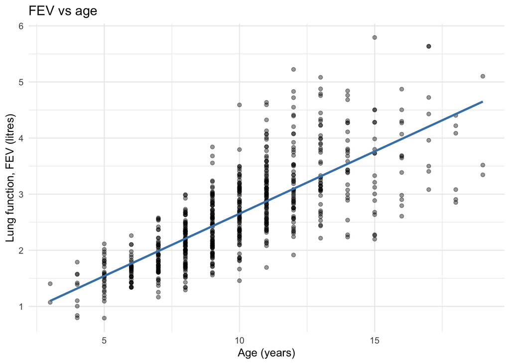

```r
ggplot(fev, aes(x = age_yrs, y = fev_l)) +
  geom_point(alpha = 0.4) +
  geom_smooth(method = "lm", se = FALSE, color = "steelblue") +
  labs(x = "Age (years)", y = "Lung function, FEV (litres)",
       title = "FEV vs age") +
  theme_minimal()
```

The cloud climbs upward. To put a single number on that, we use the **correlation coefficient `r`**, a number between -1 and +1.

- Near +1: strong positive (both rise together).
- Near -1: strong negative (one rises as the other falls).
- Near 0: no linear relationship.

Here is the correlation between **age** and FEV, worked for you:

```r
cor(fev$age_yrs, fev$fev_l)
```

```
## [1] 0.756459
```

An r of 0.76: older children tend to have larger FEV. Useful, but it is just one number. It does not give us the *equation* of the relationship, or let us predict, or tell us the units.

## 1b. Fit a line: the equation of the relationship (worked example)

A linear regression goes further: it gives the line that best describes the relationship. We fit it with `lm()`, always written `outcome ~ predictor`.

```r
model_age <- lm(fev_l ~ age_yrs, data = fev)
summary(model_age)
```

```
##
## Call:
## lm(formula = fev_l ~ age_yrs, data = fev)
##
## Residuals:
##      Min       1Q   Median       3Q      Max
## -1.57539 -0.34567 -0.04989  0.32124  2.12786
##
## Coefficients:
##             Estimate Std. Error t value Pr(>|t|)
## (Intercept) 0.431648   0.077895   5.541 4.36e-08 ***
## age_yrs     0.222041   0.007518  29.533  < 2e-16 ***
## ---
## Signif. codes:  0 '***' 0.001 '**' 0.01 '*' 0.05 '.' 0.1 ' ' 1
##
## Residual standard error: 0.5675 on 652 degrees of freedom
## Multiple R-squared:  0.5722, Adjusted R-squared:  0.5716
## F-statistic: 872.2 on 1 and 652 DF,  p-value: < 2.2e-16
```

The fitted line is `predicted FEV = 0.43 + 0.222 * age`. The **slope of 0.222** tells us, in real units, that each additional year of age is associated with about **0.22 litres** more lung capacity. Correlation could not tell us that.

## 1c. R-squared: a better summary of how well the line describes the data

The correlation and the slope each give one piece. **R-squared** ties it together: it is the proportion of the variation in the outcome that the line explains, on a clean 0-to-1 scale.

```r
glance(model_age)$r.squared
```

```
## [1] 0.5722302
```

An R-squared of 0.57: age explains about **57%** of the child-to-child variation in FEV.

Why is R-squared often more useful than the raw correlation?

- It is on an interpretable **0-1 “proportion explained”** scale, rather than the harder-to-read -1 to +1.
- It is always **positive**, so it summarizes fit without you having to track the sign separately.
- It lets you **compare models** on the same footing, including models with more than one predictor later, where a single correlation no longer applies.

(In simple regression with one predictor, R-squared is exactly the correlation squared: 0.76 squared is 0.57. The two are linked here, but R-squared keeps working when correlation runs out.)

## YOUR TURN: describe FEV using HEIGHT

Now describe the relationship between **height** (`height_in`) and FEV, and see whether height describes lung function better or worse than age does.

Fill in the blanks.

Exercise (blanked):

```r
# correlation between height and FEV
cor(__________, __________)
```

**Solution:**

```r
# correlation between height and FEV
cor(fev$height_in, fev$fev_l)
```

```
## [1] 0.868135
```

**Question:** What is the correlation between height and FEV? Is it stronger or weaker than the age correlation (0.76)?

**Answer:** The correlation is about 0.87, stronger than the age correlation of 0.76.

Exercise (blanked):

```r
# fit the line: FEV explained by height
model_height <- lm(__________ ~ __________, data = fev)
summary(model_height)
```

**Solution:**

```r
# fit the line: FEV explained by height
model_height <- lm(fev_l ~ height_in, data = fev)
summary(model_height)
```

```
##
## Call:
## lm(formula = fev_l ~ height_in, data = fev)
##
## Residuals:
##      Min       1Q   Median       3Q      Max
## -1.75167 -0.26619 -0.00401  0.24474  2.11936
##
## Coefficients:
##              Estimate Std. Error t value Pr(>|t|)
## (Intercept) -5.432679   0.181460  -29.94   <2e-16 ***
## height_in    0.131976   0.002955   44.66   <2e-16 ***
## ---
## Signif. codes:  0 '***' 0.001 '**' 0.01 '*' 0.05 '.' 0.1 ' ' 1
##
## Residual standard error: 0.4307 on 652 degrees of freedom
## Multiple R-squared:  0.7537, Adjusted R-squared:  0.7533
## F-statistic:  1995 on 1 and 652 DF,  p-value: < 2.2e-16
```

**Question:** Write the fitted equation `predicted FEV = b0 + b1 * height_in`. Interpret the slope: how much more FEV per extra inch of height?

**Answer:** `predicted FEV = -5.43 + 0.132 * height_in`. Each additional inch of height is associated with about a 0.13-litre increase in lung function.

**Question:** The intercept is about -5.4 litres (a negative, impossible lung volume). Why is the intercept not a meaningful FEV value here? (Hint: how tall is a child of height 0, and is that near the data?)

**Answer:** The intercept is the predicted FEV at a height of 0 inches, which is impossible and far below the data (the shortest child is 46 inches). Extrapolating the line all the way back to height 0 gives a negative lung volume, which is meaningless. The intercept is just the mathematical point where the line crosses the y-axis, not a real prediction.

Exercise (blanked):

```r
# R-squared for the height model
________(model_height)$r.squared
```

**Solution:**

```r
# R-squared for the height model
glance(model_height)$r.squared
```

```
## [1] 0.7536584
```

**Question:** What proportion of the variation in FEV does height explain?

**Answer:** About 0.75, so height explains roughly 75% of the variation in FEV (0.87 squared is 0.75).

**Question (the comparison):** Put the two R-squared values together: age (0.57) versus height. Which variable **describes** FEV better, and by how many percentage points? Which had the correlation closer to 1, and does that match?

**Answer:** Height describes FEV better: R-squared of about 0.75 versus about 0.57 for age, roughly 18 percentage points higher. Height also had the correlation closer to 1 (0.87 versus 0.76), which matches, because in a simple regression R-squared is exactly the correlation squared.

# PURPOSE 2: PREDICT a new child’s lung function

Once we have a fitted line, we can plug in a predictor value and read off a predicted outcome with `predict()`. Here is a prediction for a 10-year-old, using the age model (worked for you):

```r
predict(model_age, newdata = data.frame(age_yrs = 10))
```

```
##        1
## 2.652058
```

The model predicts an FEV of about 2.65 litres for a typical 10-year-old.

## YOUR TURN: predict from height

Use your `model_height` to predict the FEV of a child who is **60 inches** tall. Fill in the blank.

Exercise (blanked):

```r
predict(model_height, newdata = data.frame(height_in = ______))
```

**Solution:**

```r
predict(model_height, newdata = data.frame(height_in = 60))
```

```
##        1
## 2.485855
```

**Question:** What FEV does the model predict for a 60-inch child?

**Answer:** About 2.49 litres.

**Question:** The children in this study are between 46 and 74 inches tall. Would you trust this model to predict the FEV of a 30-inch toddler? Why or why not? (This is the danger of predicting outside the range of the data, called **extrapolation**.)

**Answer:** No. 30 inches is well below the observed range of 46 to 74 inches, so this is extrapolation: the straight line was only fit within the data range and has no support out there. The line even predicts a negative FEV for very short heights, which is impossible. Only predict within the range of the data.

# PURPOSE 3: CONTROL for other variables (a peek ahead)

The third purpose is the most powerful, and it is where regression becomes a tool for careful, almost-causal reasoning. We will only preview it here. The full method (multiple linear regression) comes in a later session.

The dataset records each child’s **smoking status** (`smoke`): whether the child or teenager is themselves a smoker. Let’s ask the obvious public-health question: is smoking associated with lung function?

First, compare average FEV by smoking status (worked for you):

```r
fev %>%
  group_by(smoke) %>%
  summarise(
    n = n(),
    mean_fev = mean(fev_l)
  )
```

```
## # A tibble: 2 × 3
##   smoke          n mean_fev
##   <chr>      <int>    <dbl>
## 1 non_smoker   589     2.57
## 2 smoker        65     3.28
```

**Question:** According to this summary, do smokers have higher or lower average lung function than non-smokers? Does that match what you would expect smoking to do to the lungs?

**Answer:** Smokers have higher average FEV (about 3.28 litres) than non-smokers (about 2.57 litres). That is the opposite of what we would expect, since smoking should harm the lungs.

That result, smokers having **higher** FEV, looks absurd. The catch is that smokers and non-smokers differ in another big way. Compare their average ages:

```r
fev %>%
  group_by(smoke) %>%
  summarise(
    mean_age = mean(age_yrs)
  )
```

```
## # A tibble: 2 × 2
##   smoke      mean_age
##   <chr>         <dbl>
## 1 non_smoker     9.53
## 2 smoker        13.5
```

**Question:** Are the smokers older or younger, on average? Combine this with Purpose 1 (older children have bigger lungs). Explain why a simple comparison makes smoking look beneficial.

**Answer:** The smokers are much older on average (about 13.5 years versus 9.5 years). Hardly any young children smoke, so the smoker group is essentially teenagers, who are bigger and have larger lungs. The simple comparison credits smoking for what is really an age difference: the smokers have bigger lungs despite smoking, not because of it.

This is exactly the problem regression’s third purpose solves. We can **control for age** by adding it to the model alongside smoking, fitting `fev_l ~ smoke + age_yrs`. This compares smokers and non-smokers *of the same age*. You have not formally learned multiple regression yet, so just run this and look at what happens to the smoking effect:

```r
# A peek at MULTIPLE regression: two predictors at once
model_controlled <- lm(fev_l ~ smoke + age_yrs, data = fev)
tidy(model_controlled)
```

```
## # A tibble: 3 × 5
##   term        estimate std.error statistic   p.value
##   <chr>          <dbl>     <dbl>     <dbl>     <dbl>
## 1 (Intercept)    0.367   0.0814       4.51 7.65e-  6
## 2 smokesmoker   -0.209   0.0807      -2.59 9.86e-  3
## 3 age_yrs        0.231   0.00818     28.2  8.28e-115
```

**Question:** Look at the `smokesmoker` row. Without controlling for age, smokers’ mean FEV was about 0.71 litres *higher*. After we add `age_yrs` to the model, what is the sign of the smoking coefficient now, positive or negative? What does that tell us about smoking and lung function once we compare children of the same age?

**Answer:** It flips to negative (about -0.21 litres). Once we compare children of the same age, smokers actually have lower lung function than non-smokers, the expected harmful direction. Adding `age_yrs` to the model held age constant and revealed the true relationship that the simple comparison had hidden. This is the power of regression’s third purpose: controlling for other variables.

**Question (wrap-up):** In your own words, summarize the three purposes of regression you have now seen (**describe**, **predict**, and **control**) in one short sentence each, using the FEV examples.

**Answer:**

- **Describe:** regression summarized how FEV relates to age or height with a slope in real units and an R-squared (height explained 75% of the variation).
- **Predict:** the fitted line let us estimate the FEV of a new child of a given height (about 2.49 litres at 60 inches).
- **Control:** adding age to the model let us compare smokers and non-smokers of the same age, flipping the misleading positive smoking association into the correct negative one.